# Precio y Rendimiento Activos

2/14/2022

En esta práctica vamos a estimar los paramétros $\mu, \sigma$ que definen la ecuación de comportamiento de un activo
$$dS=S\mu dt+S\sigma dW$$

Donde $dW=\epsilon\sqrt{dt}$ y $\epsilon$ se comporta como una normal con media cero y varianza 1.

```r
library(quantmod)
library(PerformanceAnalytics)
library(tidyverse)
library(moments)
library(lubridate)
```

```r
clave <- c("GFNORTEO.MX")
getSymbols(clave, warnings = FALSE)
```

```
## [1] "GFNORTEO.MX"
```

```r
lista <- lapply(clave, function(x) Cl(get(x)))
precio <- (do.call(merge,lista))
```

El objeto precio contiene el precio de el activo que voy a trabajar. Graficamente la evolución de este precio se ve así

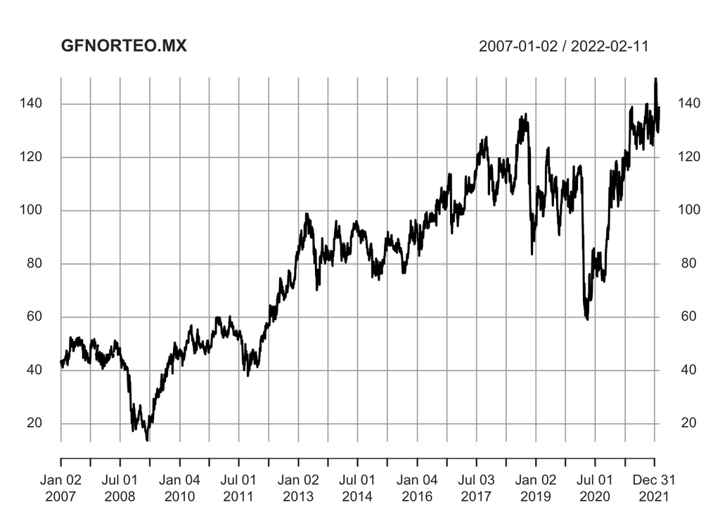

```r
plot(precio, main=clave)
```

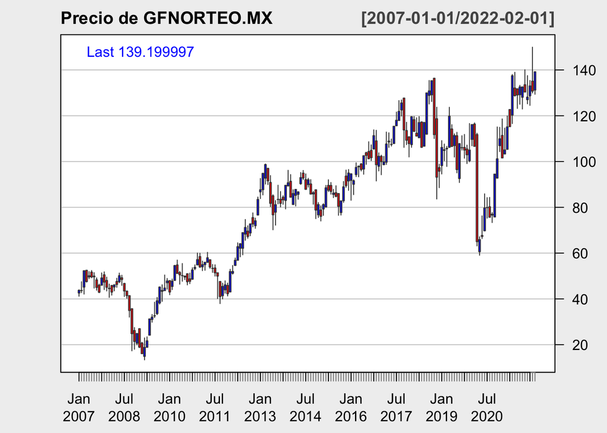

```r
chartSeries(to.monthly(precio), theme="white", up.col="blue", dn.col="red",
            name = paste("Precio de", clave))
```

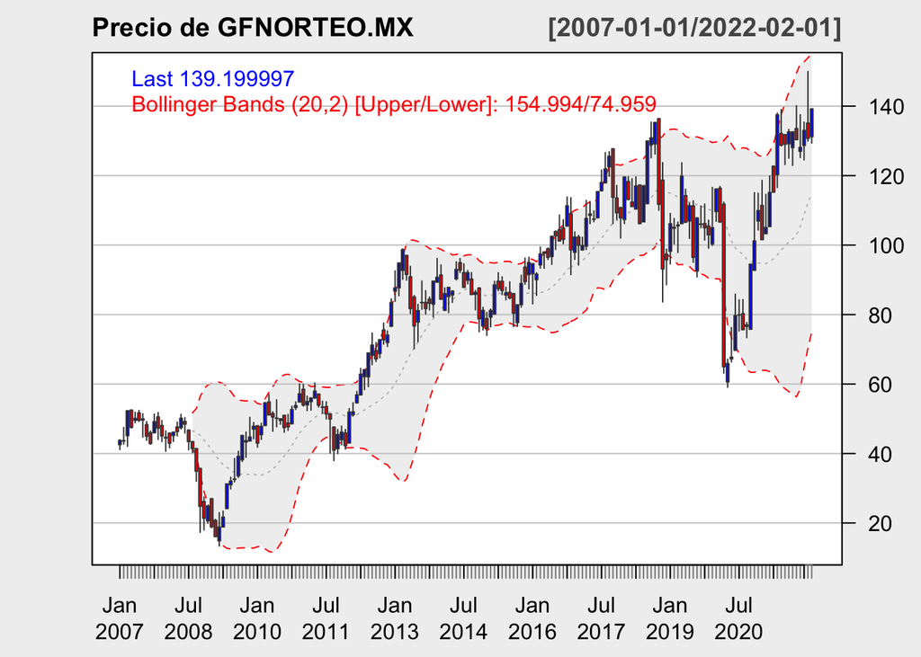

```r
addBBands()
```

Entonces ahora pues vayamos al punto, obtengamos el rendimiento del precio

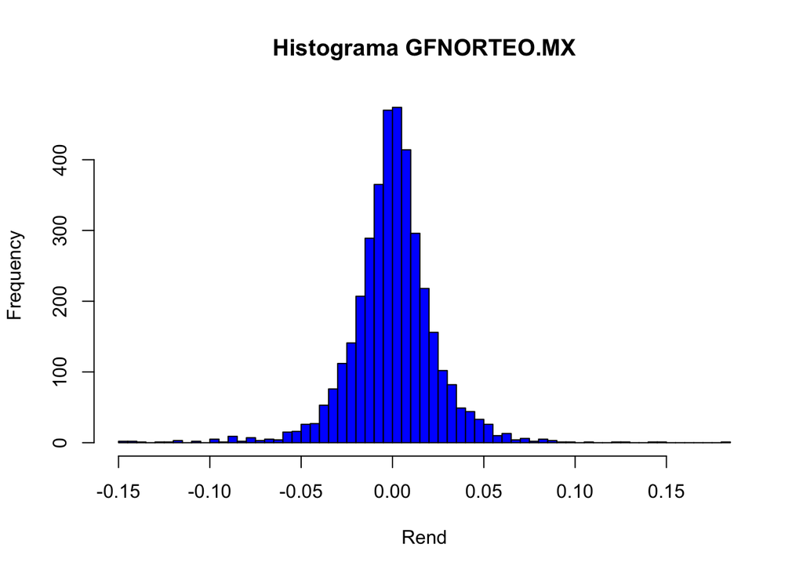

```r
Rend <- na.omit(diff(log(na.omit(precio))))
hist(Rend, n=100, main = paste("Histograma", clave), col="blue")
```

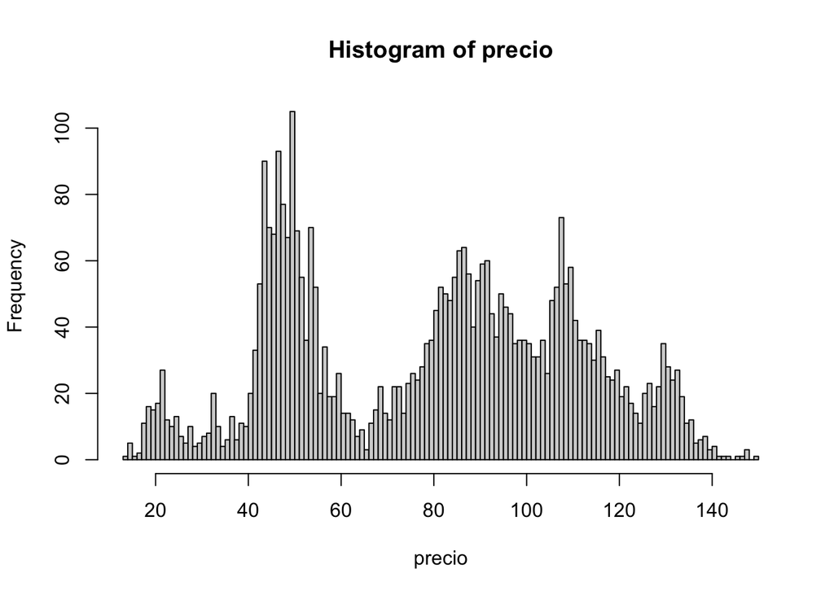

```r
hist(precio, n=100)
```

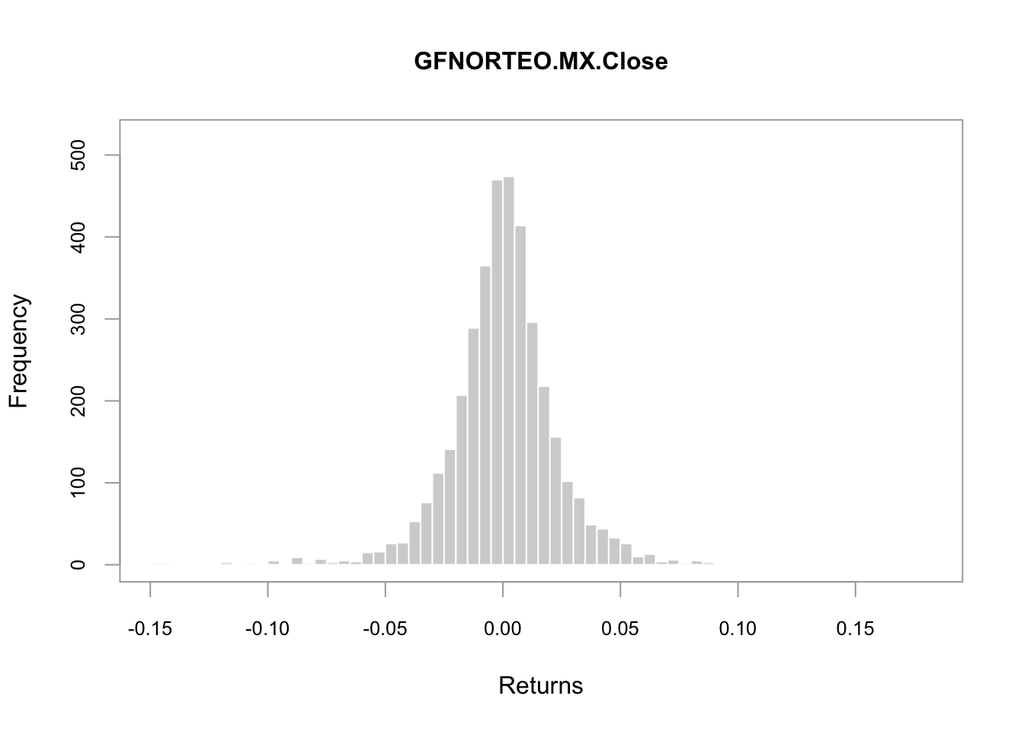

```r
chart.Histogram(Rend)
```

```r
names(precio) <- c("precio")
names(Rend) <- c("rendimiento")
Anio <- year(Rend)

Est_Prin <- Rend %>%
  as_tibble() %>%
  mutate(year=Anio) %>%
  group_by(year) %>%
  summarise(RenDiario=mean(rendimiento),
            RenAnual=mean(rendimiento)*252,
            VolDiaria=sd(rendimiento),
            VolAnual=sqrt(var(rendimiento)*252))
```

De todo el periodo

```r
Ren_Diario_Todo <- mean(Rend)
Vol_Diario_Todo <- sd(Rend)
Ren_Diario_Todo
```

```
## [1] 0.0003126021
```

```r
Vol_Diario_Todo
```

```
## [1] 0.02347176
```

Ahora vamos probar la normalidad del rendimiento de formal visual

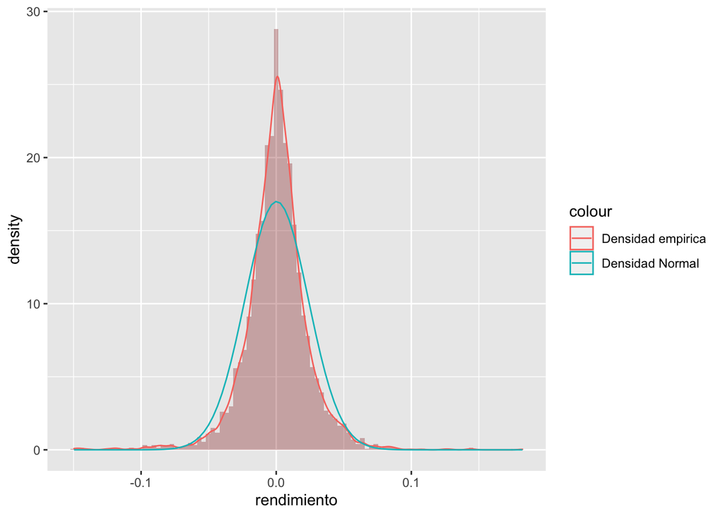

```r
Rend %>%
  as_tibble() %>%
  ggplot(aes(x=rendimiento))+
  geom_histogram(aes(y=..density..), bins = 100, fill="darkred", alpha=0.3)+
  geom_density(aes(x=rendimiento, col="Densidad empirica"))+
  stat_function(fun=dnorm, args = list(mean=Ren_Diario_Todo, sd=Vol_Diario_Todo), aes(col="Densidad Normal"))
```

En terminos formales, haremos una prueba de hipótesis.

La prueba de hipótesis para la normalidad que usaremos se llama Jarque-Bera. Esta prueba compara el sesgo y la curtosis de una distribución con la de una normal. Si el sesgo es cero y la curtosis es 3, la distribución es normal

$H_0$ normalidad en la variable

$H_a$

no hay normalidad en la variable

```r
jarque.test(as.numeric(Rend))
```

```
##
##  Jarque-Bera Normality Test
##
## data:  as.numeric(Rend)
## JB = 6230.7, p-value < 2.2e-16
## alternative hypothesis: greater
```

Si p-value es menor a 0.01 podemos rechazar Ho con un 99% de certeza que no estamos cometiendo un error. Entonces mi conclusión es que debo rechazar Ho, por lo tanto rechazo las posibilidades de que sea Normal.

```r
kurtosis(Rend)
```

```
## rendimiento
##    9.256101
```

```r
skewness(Rend)
```

```
## rendimiento
##  -0.2814838
```